# Projeto Final

Anderson Caio Emerson Tiago Vinicius

2023-06-17

# Projeto Integrado – final

A QuantumFinance está acompanhando um crescimento de inadimplência entre seus clientes e solicita a consultoria para desenvolver uma análise de inadimplência.

Os resultados apresentados pela consultoria mostram que o modelo de credit scoring implementado utilizou 70 variáveis e apresentou uma acurácia de 26% (R2 ajustado = 0.2593609). Consequentemente, a QuantumFinance está oferecendo crédito para mau pagador e deixando de oferecer para o bom pagador.

Para que a QuantumFinance tome decisões mais precisas sobre concessões de crédito, ela precisa aprimorar seu modelo de concessão de crédito.

Desafio: Melhorar a acurácia do modelo preditivo mediante uso do valor target disponível na base de dados train.csv.

## 3ª etapa: Conhecer os dados

A base de dados contém uma coluna chamada id que identifica exclusivamente cada linha, várias colunas identificadas por strings hexadecimais e um destino de coluna que gostaríamos que você previsse. As colunas que contêm hashes SHA-256 para seus valores representam variáveis categóricas, enquanto o restante das variáveis é numérica. O arquivo test.csv tem os mesmos nomes de coluna e tipos de dados que train.csv, mas está faltando a coluna da variável resposta. Não há valores ausentes ou problemas de corrupção de dados em nenhum desses arquivos. Não se preocupe com os significados das variáveis ou dos metadados - este é um conjunto de dados artificial.

| Variável | Tipo da variável (natureza) |
| --- | --- |
| 016399044a | Quantitativa discreta |
| 023c68873b | Qualitativa nominal |
| 0342faceb5 | Quantitativa discreta |
| 04e7268385 | Quantitativa discreta |
| 06888ceac9 | Qualitativa nominal |
| 072b7e8f27 | Quantitativa contínua |
| 087235d61e | Quantitativa discreta |
| 0b846350ef | Quantitativa contínua |
| 0e2ab0831c | Quantitativa contínua |
| 12eda2d982 | Quantitativa contínua |
| 136c1727c3 | Quantitativa contínua |
| 173b6590ae | Quantitativa contínua |
| 174825d438 | Quantitativa discreta |
| 1f222e3669 | Quantitativa contínua |
| 1f3058af83 | Quantitativa discreta |
| 1fa099bb01 | Quantitativa discreta |
| 20f1afc5c7 | Quantitativa contínua |
| 253eb5ef11 | Quantitativa contínua |
| 25bbf0e7e7 | Quantitativa discreta |
| 2719b72c0d | Quantitativa contínua |
| 298ed82b22 | Quantitativa contínua |
| 29bbd86997 | Quantitativa contínua |
| 2a457d15d9 | Quantitativa discreta |
| 2bc6ab42f7 | Quantitativa contínua |
| 2d7fe4693a | Quantitativa contínua |
| 2e874bc151 | Quantitativa contínua |
| 361f93f4d1 | Qualitativa nominal |
| 384bec5dd1 | Qualitativa nominal |
| 3df2300fa2 | Quantitativa contínua |
| 3e200bf766 | Quantitativa discreta |

[output cut: 78 more lines]

## 4ª etapa: Preencher o quadro conceitual estatístico.

| Variável | Tipo da variável (natureza) |
| --- | --- |
| 1. Plano Básico de Análise | 1. Importação dos dados. |
|  | 2. Limpeza e pré-processamento dos dados. |
|  | 3. Análise exploratória dos dados. |
|  | 4. Criação de gráficos e visualizações. |
|  | 5. Teste de hipóteses ou comparação de grupos. |
|  | 6. Ajuste de modelos estatísticos. |
|  | 7. Avaliação da qualidade do modelo. |
|  | 8. Interpretação dos resultados. |
|  | 9. Comunicação dos resultados de forma clara e concisa. |

```r
# nao mostrar os resultados na notacao cientifica
options(scipen = 999)
```

## 5ª etapa: Faça a análise descritiva das variáveis. Apresente os gráficos e as medidas resumos.

### Import de pacotes utilizados

```r
library(tidyverse)
library(ggplot2)
library(summarytools)
library(gmodels)
library(dplyr)
library(fastDummies)
```

### Leitura dos dados train.csv

```r
library(readr)
df <- read_csv("./data/train.csv")
```

Os dados apresentam nomes de colunas dificeis de serem identificadas, então o primeiro passo foi converter todas as colunas das variáveis preditoras para x1,x2,x3,…,xn e criar um dicionario pra identificalas.

```r
# Nomes das colunas que você quer renomear
colunas_para_renomear <- setdiff(names(df), c("id", "target"))

# Número de colunas para renomear
num_colunas <- length(colunas_para_renomear)

# Inicializando o dicionário
dicionario <- list()

# Renomear as colunas para x1, x2, x3, ... e criar o dicionario
for (i in 1:num_colunas) {
    colname <- colunas_para_renomear[i]
    new_colname <- paste("x", i, sep="")

    # Adicionando ao dicionário
    dicionario[[new_colname]] <- colname

    print(paste(colname, "->", new_colname))

    # Renomeando a coluna
    names(df)[names(df) == colname] <- new_colname
}
```

```
## [1] "016399044a -> x1"
## [1] "023c68873b -> x2"
## [1] "0342faceb5 -> x3"
## [1] "04e7268385 -> x4"
## [1] "06888ceac9 -> x5"
## [1] "072b7e8f27 -> x6"
## [1] "087235d61e -> x7"
## [1] "0b846350ef -> x8"
## [1] "0e2ab0831c -> x9"
## [1] "12eda2d982 -> x10"
## [1] "136c1727c3 -> x11"
## [1] "173b6590ae -> x12"
## [1] "174825d438 -> x13"
## [1] "1f222e3669 -> x14"
## [1] "1f3058af83 -> x15"
```

[output cut: 91 more lines]

Durante nossa analise identificamos todas as variaveis qualitativas e as transformamos em variaveis do tipo factor.

```r
df$x2 <- factor(df$x2)
df$x5 <- factor(df$x5)
df$x27 <- factor(df$x27)
df$x28 <- factor(df$x28)
df$x53 <- factor(df$x53, ordered=TRUE)
df$x59 <- factor(df$x59)
df$x62 <- factor(df$x62)
df$x67 <- factor(df$x67)
df$x78 <- factor(df$x78)
df$x91 <- factor(df$x91)
df$x100 <- factor(df$x100)
```

Com as variaveis devidamente transformadas fazemos a analise descritiva(Conhecer as variaveis):

```r
# medidas resumo
summary(df)
```

```
##        x1                                      x2              x3
##  Min.   :6129   369c07e037bdf9071badfa06c0f6ef4e:   59   Min.   :5040
##  1st Qu.:6398   c0f379d9af329b0213f319e69a97c4a6:   57   1st Qu.:5292
##  Median :6452   8f41b2d9ac870e4e2211b7f8c77b8015:   56   Median :5339
##  Mean   :6452   a61b6349dc22d541cb2bf767cba9a84b:   56   Mean   :5339
##  3rd Qu.:6507   ce46ea842bf36508eb7405ee3241a4c5:   55   3rd Qu.:5385
##  Max.   :6805   58586eae2b39d07886d0906440df8c02:   54   Max.   :5595
##                 (Other)                         :24639
##        x4        x5              x6               x7
##  Min.   :35132   0: 3505   Min.   :-131.5   Min.   :-33.00
##  1st Qu.:35717   1:21471   1st Qu.: 279.5   1st Qu.: 10.00
##  Median :35843             Median : 573.0   Median : 24.00
##  Mean   :35844             Mean   : 789.3   Mean   : 37.87
##  3rd Qu.:35971             3rd Qu.:1074.7   3rd Qu.: 65.00
##  Max.   :36617             Max.   :7683.0   Max.   :155.00
##
##        x8                  x9                 x10               x11
##  Min.   :-534285.1   Min.   :-4801.982   Min.   :  6.357   Min.   : 0.210
##  1st Qu.:     -1.0   1st Qu.:   -0.973   1st Qu.: 32.500   1st Qu.: 1.837
##  Median :      0.0   Median :    0.008   Median : 42.081   Median : 2.707
##  Mean   :    -21.2   Mean   :   -0.147   Mean   : 44.045   Mean   : 3.216
##  3rd Qu.:      1.0   3rd Qu.:    1.006   3rd Qu.: 53.661   3rd Qu.: 4.016
##  Max.   :   8511.2   Max.   : 3263.127   Max.   :136.076   Max.   :31.790
##
##       x12              x13             x14             x15
##  Min.   :0.2129   Min.   :    4   Min.   :15.23   Min.   :34686
##  1st Qu.:0.8380   1st Qu.:12398   1st Qu.:21.87   1st Qu.:35379
##  Median :0.9485   Median :25072   Median :28.33   Median :35506
##  Mean   :0.9349   Mean   :25004   Mean   :28.35   Mean   :35507
##  3rd Qu.:1.0465   3rd Qu.:37493   3rd Qu.:34.91   3rd Qu.:35634
##  Max.   :1.3967   Max.   :49952   Max.   :41.37   Max.   :36323
##
##       x16              x17               x18                 x19
##  Min.   :-64.00   Min.   : 0.0002   Min.   :0.0000029   Min.   :-91.00
##  1st Qu.: 16.00   1st Qu.: 2.4376   1st Qu.:0.2247037   1st Qu.: 17.00
##  Median : 28.00   Median : 5.8543   Median :0.4995968   Median : 23.00
##  Mean   : 41.42   Mean   : 8.4452   Mean   :0.5002357   Mean   : 42.27
##  3rd Qu.: 63.00   3rd Qu.:11.7095   3rd Qu.:0.7757522   3rd Qu.: 66.00
##  Max.   :212.00   Max.   :86.1792   Max.   :0.9999775   Max.   :223.00
##
```

[output cut: 185 more lines]

```
##  Min.   : 846.0   Min.   :0.000259   Min.   : 0.236   Min.   : 0.3315
##  1st Qu.: 977.0   1st Qu.:1.000519   1st Qu.:14.890   1st Qu.: 1.8503
##  Median : 997.0   Median :1.000597   Median :26.957   Median : 2.6993
##  Mean   : 996.9   Mean   :0.973738   Mean   :27.027   Mean   : 3.1630
##  3rd Qu.:1017.0   3rd Qu.:1.000674   3rd Qu.:39.215   3rd Qu.: 3.9484
##  Max.   :1111.0   Max.   :1.001109   Max.   :61.403   Max.   :24.3726
##
##        id            target
##  Min.   :    0   Min.   :-0.2398
##  1st Qu.: 6244   1st Qu.: 0.5031
##  Median :12488   Median : 0.9838
##  Mean   :12488   Mean   : 1.6609
##  3rd Qu.:18731   3rd Qu.: 1.9680
##  Max.   :24975   Max.   :61.3261
##
```

### Grafico univariado da target

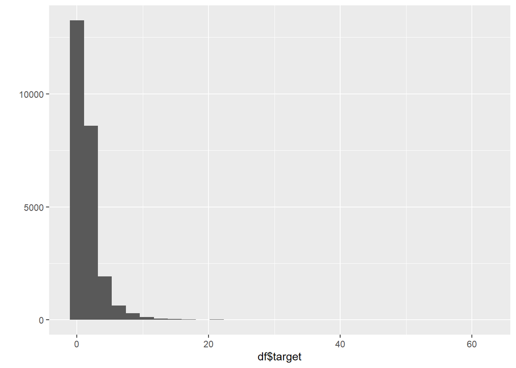

```r
# grafico de uma variavel
qplot(x=df$target)
```

#### Separamos as variaveis quantitativas, qualitativas e a variavel target para fazermos manipulações de maneira mais facil

```r
dadosQuali <- df %>%
  select(x2,x5,x27,x28,x53,x59,x62,x67,x78,x91,x100)

dadosQuant <- df %>%
  select(-c(id,target,x2,x5,x27,x28,x53,x59,x62,x67,x78,x91,x100))

target <- df$target
```

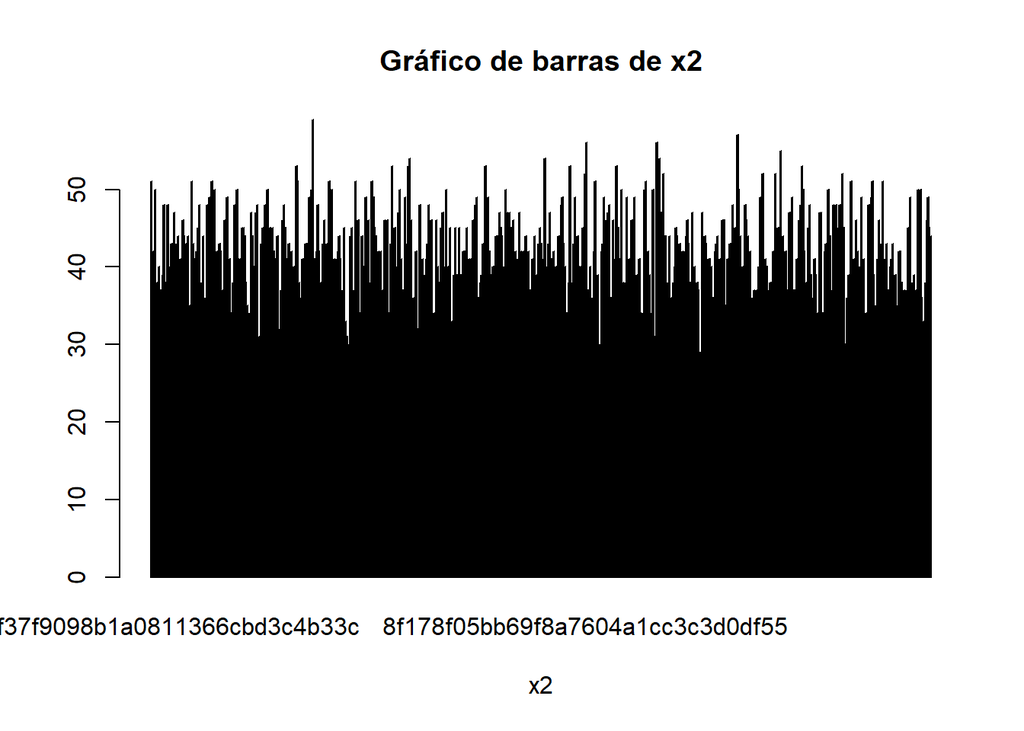

```r
# Gráficos de barras para x2 e x5
barplot(table(df$x2), main="Gráfico de barras de x2", xlab="x2")
```

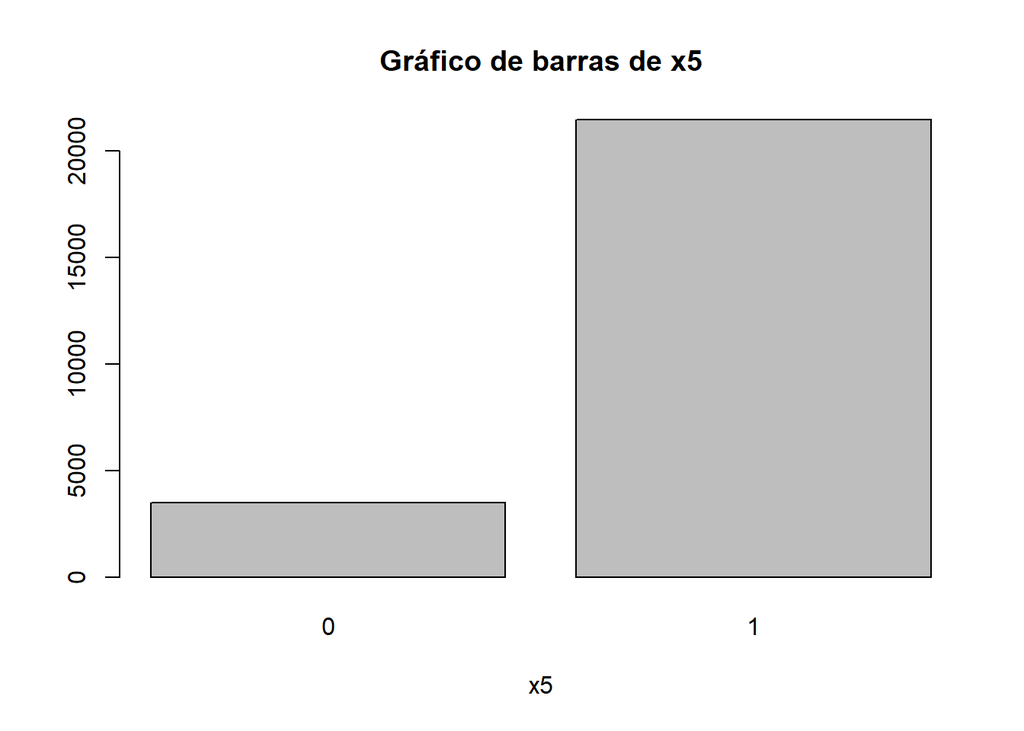

```r
barplot(table(df$x5), main="Gráfico de barras de x5", xlab="x5")
```

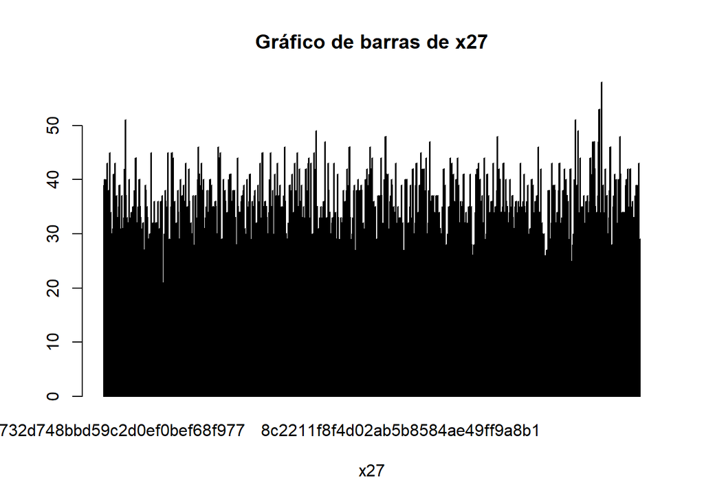

```r
barplot(table(df$x27), main="Gráfico de barras de x27", xlab="x27")
```

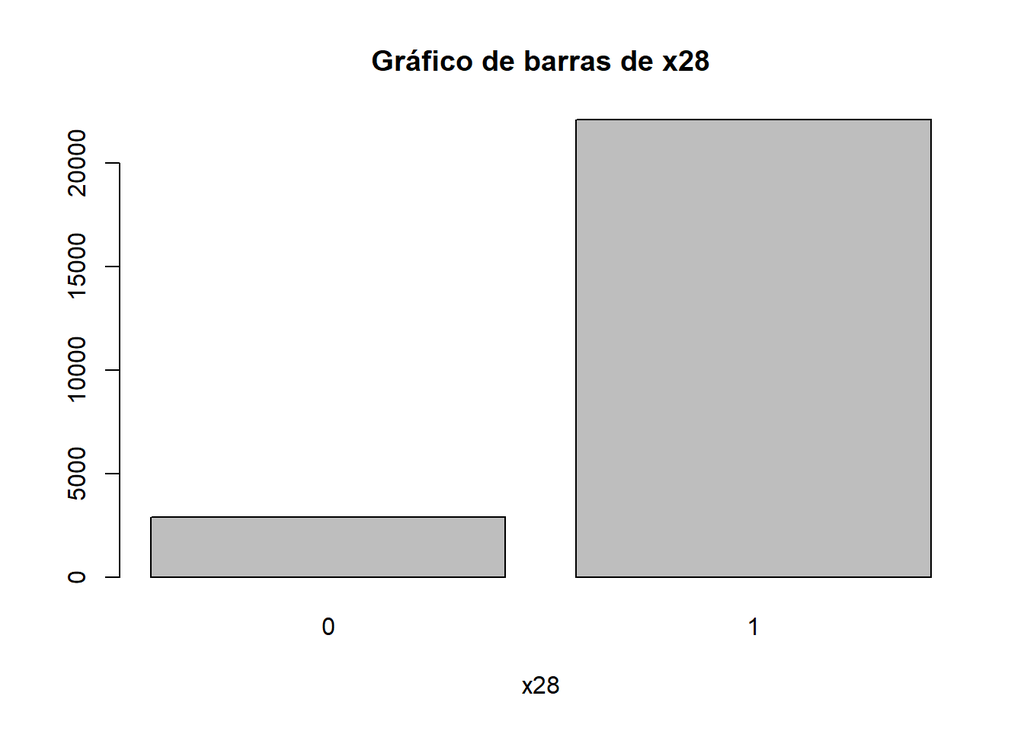

```r
barplot(table(df$x28), main="Gráfico de barras de x28", xlab="x28")
```

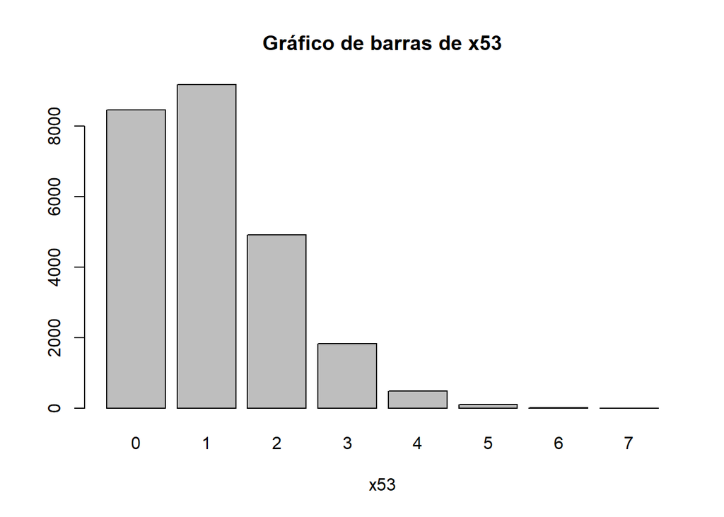

```r
barplot(table(df$x53), main="Gráfico de barras de x53", xlab="x53")
```

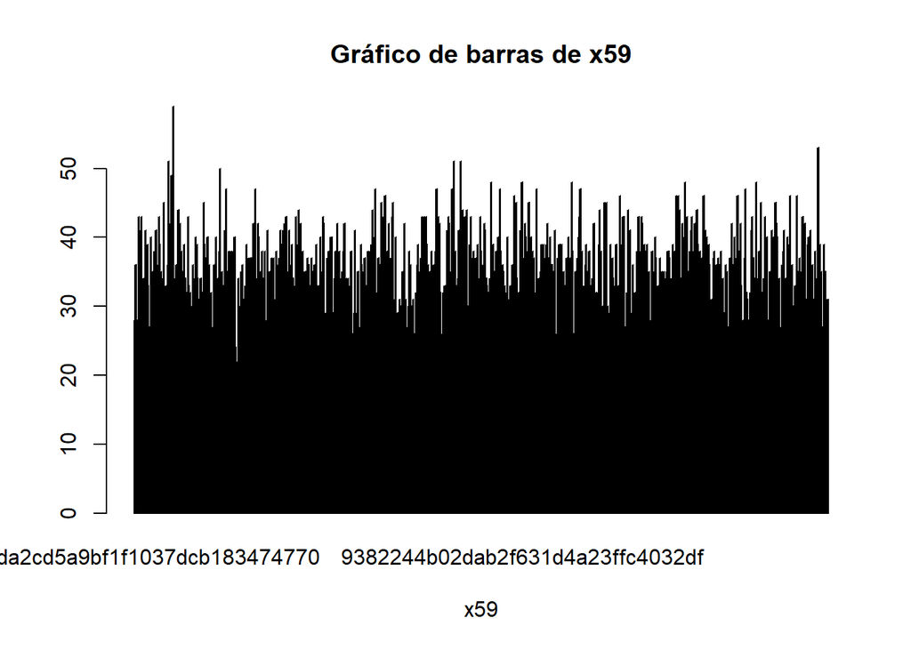

```r
barplot(table(df$x59), main="Gráfico de barras de x59", xlab="x59")
```

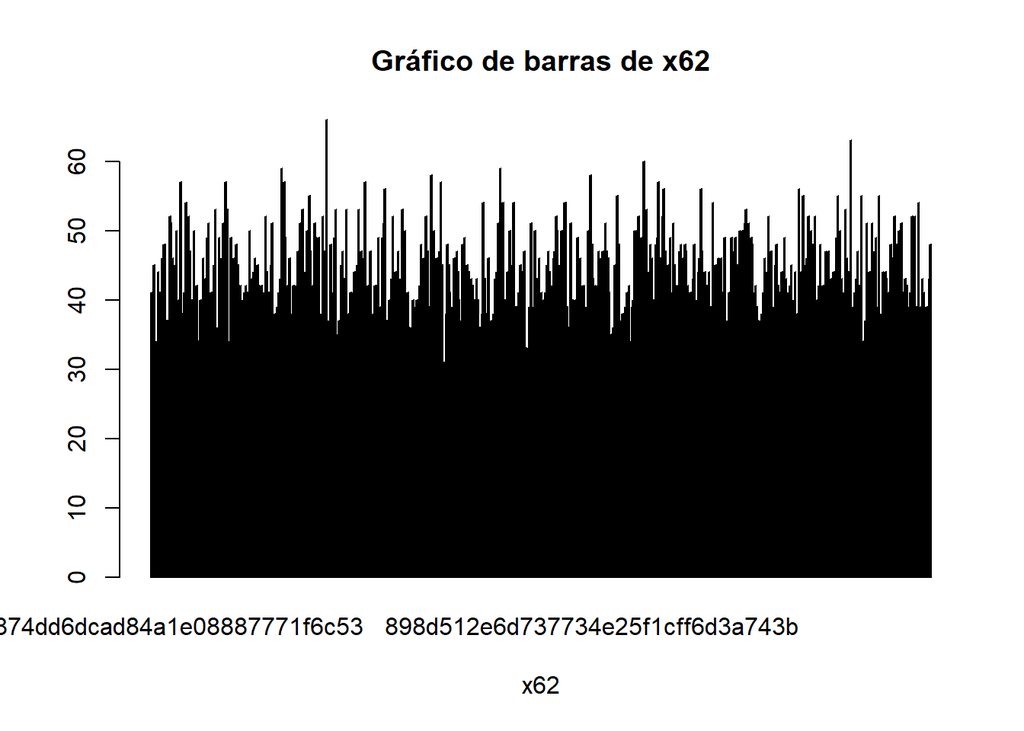

```r
barplot(table(df$x62), main="Gráfico de barras de x62", xlab="x62")
```

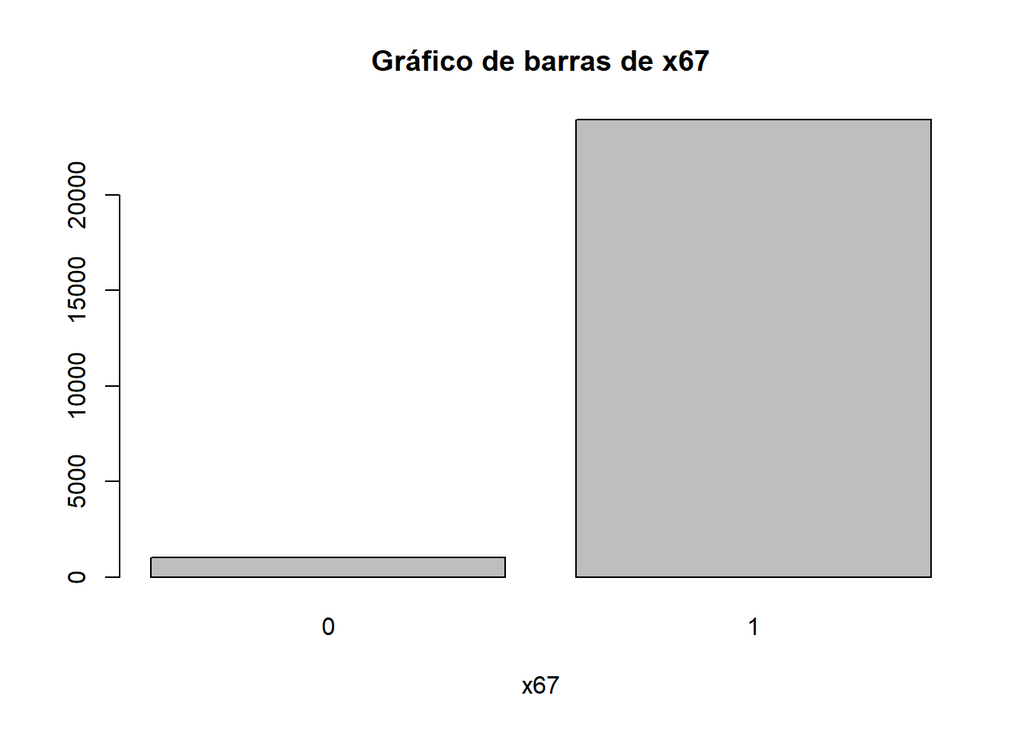

```r
barplot(table(df$x67), main="Gráfico de barras de x67", xlab="x67")
```

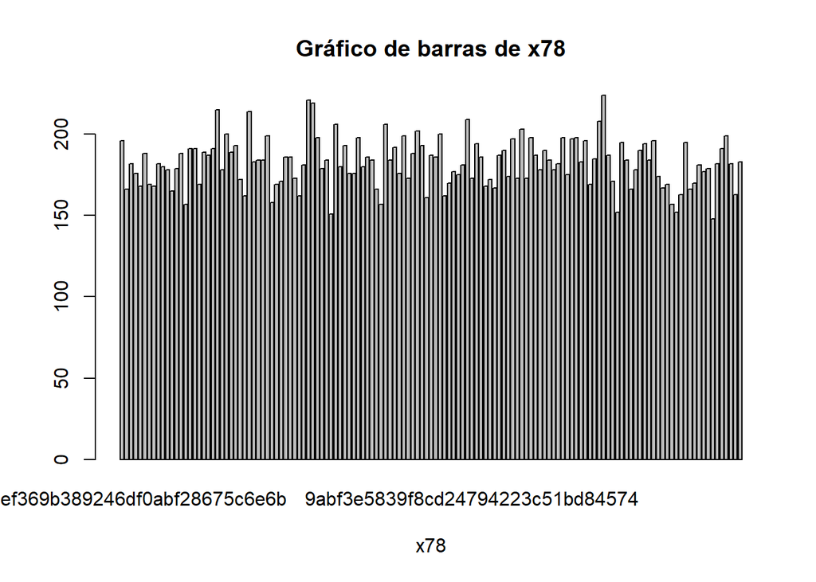

```r
barplot(table(df$x78), main="Gráfico de barras de x78", xlab="x78")
```

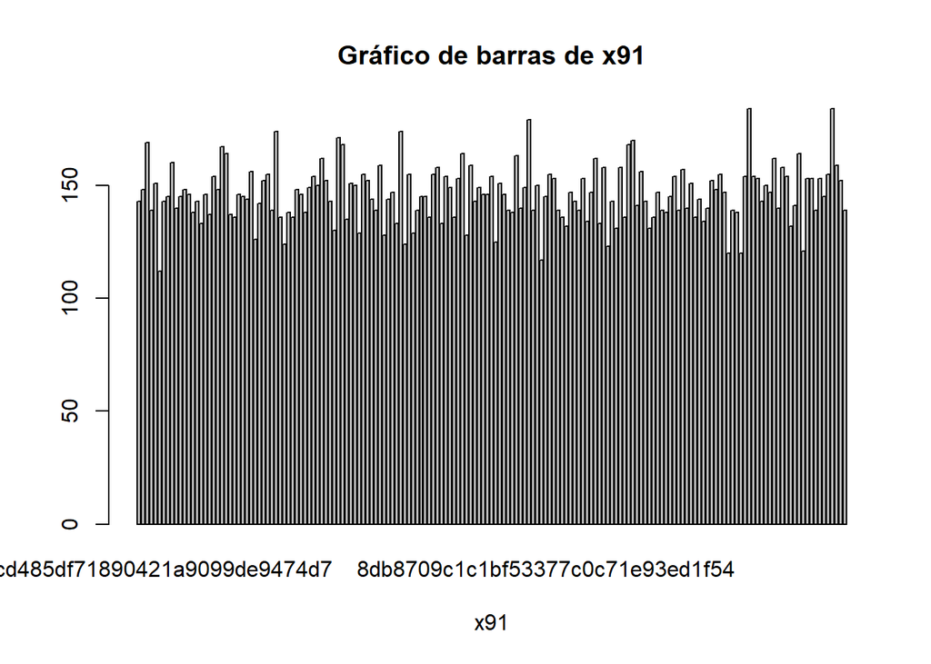

```r
barplot(table(df$x91), main="Gráfico de barras de x91", xlab="x91")
```

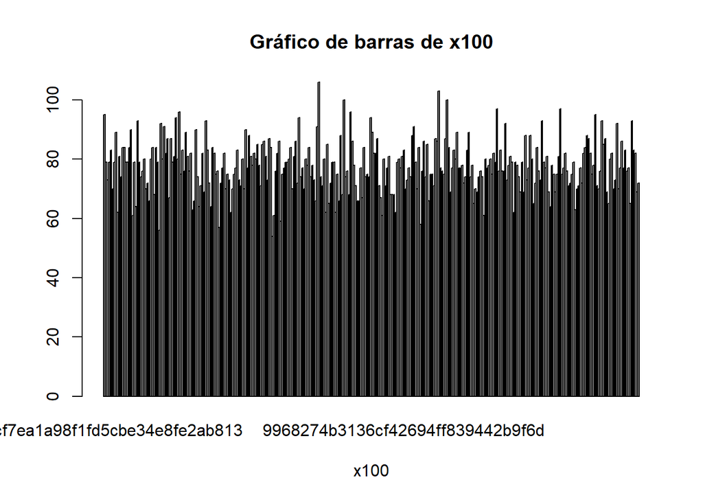

```r
barplot(table(df$x100), main="Gráfico de barras de x100", xlab="x100")
```

# 6ª etapa: Faça a análise bivariada das variáveis qualitativas.

Analise da variavel target vs x53, x5, x28 e x67

Primeiro passo: transformar a variavel quantitativa (target) em uma qualitativa (faixa de target)

Criterio: fórmula de Sturges

```r
# Calcular o número de bins usando a fórmula de Sturges
n <- length(df$target)
k <- round(1 + 3.322 * log10(n))
```

#### Para análise bivariada das variáveis qualitativas criamos as faixas de valores para variavel target.

```r
# Criar a variável faixa de target
df1 <- df

# Usando cut para criar as faixas e labels apropriadas
df1$fxtarget_cat <- cut(df$target, breaks = k, include.lowest = TRUE, dig.lab = 10)

# Converter para um fator ordenado
df1$fxtarget_cat <- factor(df1$fxtarget_cat, ordered = TRUE)

# Mostrando as frequências das faixas
freq(df1$fxtarget_cat)
```

```
## Frequencies
## df1$fxtarget_cat
## Type: Ordered Factor
##
##                                      Freq   % Valid   % Valid Cum.   % Total   % Total Cum.
## --------------------------------- ------- --------- -------------- --------- --------------
##       [-0.3014040834,3.608034849]   22429    89.802         89.802    89.802         89.802
##         (3.608034849,7.455907814]    1953     7.820         97.622     7.820         97.622
##         (7.455907814,11.30378078]     397     1.590         99.211     1.590         99.211
##         (11.30378078,15.15165374]     105     0.420         99.632     0.420         99.632
##         (15.15165374,18.99952671]      40     0.160         99.792     0.160         99.792
##         (18.99952671,22.84739967]      25     0.100         99.892     0.100         99.892
##         (22.84739967,26.69527264]      13     0.052         99.944     0.052         99.944
##          (26.69527264,30.5431456]       2     0.008         99.952     0.008         99.952
##          (30.5431456,34.39101857]       2     0.008         99.960     0.008         99.960
##         (34.39101857,38.23889153]       3     0.012         99.972     0.012         99.972
##          (38.23889153,42.0867645]       2     0.008         99.980     0.008         99.980
##          (42.0867645,45.93463746]       1     0.004         99.984     0.004         99.984
##         (45.93463746,49.78251043]       3     0.012         99.996     0.012         99.996
##         (57.47825636,61.38769529]       1     0.004        100.000     0.004        100.000
##                              <NA>       0                              0.000        100.000
##                             Total   24976   100.000        100.000   100.000        100.000
```

### a) Tabela de frequência bivariada

### b) Teste Qui-quadrado.

Como resultado do CrossTable temos uma tabela de frequência bivariada que compara duas variáveis categóricas e tambem ja nos apresenta o teste Qui-quadrado como output.

Statistics for All Table Factors: Nesta seção, temos o resultado do teste qui-quadrado de Pearson que testa a independência entre as duas variáveis categóricas.

- Chi^2: O valor da estatística qui-quadrado.
- d.f.: Os graus de liberdade para o teste.
- p: O valor-p associado ao teste qui-quadrado. quando este valor é extremamente próximo de 0, sugere que podemos rejeitar a hipótese nula de que as duas variáveis são independentes.

CrossTable (x53 e target)

```r
df1$quali_x53 <- factor(df1$x53)

CrossTable(df1$fxtarget_cat,df1$quali_x53, prop.r = FALSE, prop.c = FALSE, prop.t = FALSE,
           prop.chisq = FALSE,chisq = TRUE)
```

```
##
##
##    Cell Contents
## |-------------------------|
## |                       N |
## |-------------------------|
##
##
## Total Observations in Table:  24976
##
##
##                             | df1$quali_x53
##            df1$fxtarget_cat |         0 |         1 |         2 |         3 |         4 |         5 |         6 |         7 | Row Total |
## ----------------------------|-----------|-----------|-----------|-----------|-----------|-----------|-----------|-----------|-----------|
## [-0.3014040834,3.608034849] |      7602 |      8249 |      4409 |      1640 |       423 |        89 |        15 |         2 |     22429 |
## ----------------------------|-----------|-----------|-----------|-----------|-----------|-----------|-----------|-----------|-----------|
##   (3.608034849,7.455907814] |       657 |       708 |       381 |       152 |        44 |         9 |         2 |         0 |      1953 |
## ----------------------------|-----------|-----------|-----------|-----------|-----------|-----------|-----------|-----------|-----------|
##   (7.455907814,11.30378078] |       129 |       139 |        91 |        28 |        10 |         0 |         0 |         0 |       397 |
## ----------------------------|-----------|-----------|-----------|-----------|-----------|-----------|-----------|-----------|-----------|
##   (11.30378078,15.15165374] |        46 |        36 |        14 |         7 |         1 |         1 |         0 |         0 |       105 |
## ----------------------------|-----------|-----------|-----------|-----------|-----------|-----------|-----------|-----------|-----------|
##   (15.15165374,18.99952671] |        13 |        16 |         7 |         2 |         2 |         0 |         0 |         0 |        40 |
## ----------------------------|-----------|-----------|-----------|-----------|-----------|-----------|-----------|-----------|-----------|
##   (18.99952671,22.84739967] |         5 |        12 |         7 |         0 |         1 |         0 |         0 |         0 |        25 |
## ----------------------------|-----------|-----------|-----------|-----------|-----------|-----------|-----------|-----------|-----------|
##   (22.84739967,26.69527264] |         2 |         9 |         2 |         0 |         0 |         0 |         0 |         0 |        13 |
## ----------------------------|-----------|-----------|-----------|-----------|-----------|-----------|-----------|-----------|-----------|
##    (26.69527264,30.5431456] |         0 |         1 |         1 |         0 |         0 |         0 |         0 |         0 |         2 |
## ----------------------------|-----------|-----------|-----------|-----------|-----------|-----------|-----------|-----------|-----------|
##    (30.5431456,34.39101857] |         0 |         0 |         2 |         0 |         0 |         0 |         0 |         0 |         2 |
## ----------------------------|-----------|-----------|-----------|-----------|-----------|-----------|-----------|-----------|-----------|
##   (34.39101857,38.23889153] |         1 |         0 |         2 |         0 |         0 |         0 |         0 |         0 |         3 |
## ----------------------------|-----------|-----------|-----------|-----------|-----------|-----------|-----------|-----------|-----------|
##    (38.23889153,42.0867645] |         0 |         1 |         0 |         1 |         0 |         0 |         0 |         0 |         2 |
## ----------------------------|-----------|-----------|-----------|-----------|-----------|-----------|-----------|-----------|-----------|
##    (42.0867645,45.93463746] |         0 |         1 |         0 |         0 |         0 |         0 |         0 |         0 |         1 |
## ----------------------------|-----------|-----------|-----------|-----------|-----------|-----------|-----------|-----------|-----------|
##   (45.93463746,49.78251043] |         0 |         2 |         1 |         0 |         0 |         0 |         0 |         0 |         3 |
## ----------------------------|-----------|-----------|-----------|-----------|-----------|-----------|-----------|-----------|-----------|
##   (57.47825636,61.38769529] |         0 |         1 |         0 |         0 |         0 |         0 |         0 |         0 |         1 |
## ----------------------------|-----------|-----------|-----------|-----------|-----------|-----------|-----------|-----------|-----------|
##                Column Total |      8455 |      9175 |      4917 |      1830 |       481 |        99 |        17 |         2 |     24976 |
## ----------------------------|-----------|-----------|-----------|-----------|-----------|-----------|-----------|-----------|-----------|
##
##
## Statistics for All Table Factors
##
##
## Pearson's Chi-squared test
## ------------------------------------------------------------
## Chi^2 =  56.49066     d.f. =  91     p =  0.9982963
##
##
##
```

CrossTable (x5 e target)

```r
df1$quali_x5 <- factor(df1$x5)

CrossTable(df1$fxtarget_cat,df1$quali_x5, prop.r = FALSE, prop.c = FALSE, prop.t = FALSE,
           prop.chisq = FALSE,chisq = TRUE)
```

```
##
##
##    Cell Contents
## |-------------------------|
## |                       N |
## |-------------------------|
##
##
## Total Observations in Table:  24976
##
##
##                             | df1$quali_x5
##            df1$fxtarget_cat |         0 |         1 | Row Total |
## ----------------------------|-----------|-----------|-----------|
## [-0.3014040834,3.608034849] |      2901 |     19528 |     22429 |
## ----------------------------|-----------|-----------|-----------|
##   (3.608034849,7.455907814] |       446 |      1507 |      1953 |
## ----------------------------|-----------|-----------|-----------|
##   (7.455907814,11.30378078] |        96 |       301 |       397 |
## ----------------------------|-----------|-----------|-----------|
##   (11.30378078,15.15165374] |        32 |        73 |       105 |
## ----------------------------|-----------|-----------|-----------|
##   (15.15165374,18.99952671] |        12 |        28 |        40 |
## ----------------------------|-----------|-----------|-----------|
##   (18.99952671,22.84739967] |         8 |        17 |        25 |
## ----------------------------|-----------|-----------|-----------|
##   (22.84739967,26.69527264] |         4 |         9 |        13 |
## ----------------------------|-----------|-----------|-----------|
##    (26.69527264,30.5431456] |         2 |         0 |         2 |
## ----------------------------|-----------|-----------|-----------|
##    (30.5431456,34.39101857] |         2 |         0 |         2 |
## ----------------------------|-----------|-----------|-----------|
##   (34.39101857,38.23889153] |         2 |         1 |         3 |
## ----------------------------|-----------|-----------|-----------|
##    (38.23889153,42.0867645] |         0 |         2 |         2 |
## ----------------------------|-----------|-----------|-----------|
##    (42.0867645,45.93463746] |         0 |         1 |         1 |
## ----------------------------|-----------|-----------|-----------|
##   (45.93463746,49.78251043] |         0 |         3 |         3 |
## ----------------------------|-----------|-----------|-----------|
##   (57.47825636,61.38769529] |         0 |         1 |         1 |
## ----------------------------|-----------|-----------|-----------|
##                Column Total |      3505 |     21471 |     24976 |
## ----------------------------|-----------|-----------|-----------|
##
##
## Statistics for All Table Factors
##
##
## Pearson's Chi-squared test
## ------------------------------------------------------------
## Chi^2 =  256.037     d.f. =  13     p =  0.00000000000000000000000000000000000000000000003564283
##
##
##
```

CrossTable (x28 e target)

```r
df1$quali_x28 <- factor(df1$x28)

CrossTable(df1$fxtarget_cat,df1$quali_x28, prop.r = FALSE, prop.c = FALSE, prop.t = FALSE,
           prop.chisq = FALSE,chisq = TRUE)
```

```
##
##
##    Cell Contents
## |-------------------------|
## |                       N |
## |-------------------------|
##
##
## Total Observations in Table:  24976
##
##
##                             | df1$quali_x28
##            df1$fxtarget_cat |         0 |         1 | Row Total |
## ----------------------------|-----------|-----------|-----------|
## [-0.3014040834,3.608034849] |      2618 |     19811 |     22429 |
## ----------------------------|-----------|-----------|-----------|
##   (3.608034849,7.455907814] |       222 |      1731 |      1953 |
## ----------------------------|-----------|-----------|-----------|
##   (7.455907814,11.30378078] |        37 |       360 |       397 |
## ----------------------------|-----------|-----------|-----------|
##   (11.30378078,15.15165374] |        12 |        93 |       105 |
## ----------------------------|-----------|-----------|-----------|
##   (15.15165374,18.99952671] |         3 |        37 |        40 |
## ----------------------------|-----------|-----------|-----------|
##   (18.99952671,22.84739967] |         1 |        24 |        25 |
## ----------------------------|-----------|-----------|-----------|
##   (22.84739967,26.69527264] |         2 |        11 |        13 |
## ----------------------------|-----------|-----------|-----------|
##    (26.69527264,30.5431456] |         0 |         2 |         2 |
## ----------------------------|-----------|-----------|-----------|
##    (30.5431456,34.39101857] |         1 |         1 |         2 |
## ----------------------------|-----------|-----------|-----------|
##   (34.39101857,38.23889153] |         1 |         2 |         3 |
## ----------------------------|-----------|-----------|-----------|
##    (38.23889153,42.0867645] |         0 |         2 |         2 |
## ----------------------------|-----------|-----------|-----------|
##    (42.0867645,45.93463746] |         0 |         1 |         1 |
## ----------------------------|-----------|-----------|-----------|
##   (45.93463746,49.78251043] |         0 |         3 |         3 |
## ----------------------------|-----------|-----------|-----------|
##   (57.47825636,61.38769529] |         0 |         1 |         1 |
## ----------------------------|-----------|-----------|-----------|
##                Column Total |      2897 |     22079 |     24976 |
## ----------------------------|-----------|-----------|-----------|
##
##
## Statistics for All Table Factors
##
##
## Pearson's Chi-squared test
## ------------------------------------------------------------
## Chi^2 =  9.918561     d.f. =  13     p =  0.7005799
##
##
##
```

CrossTable (x67 e target)

```r
df1$quali_x67 <- factor(df1$x67)

CrossTable(df1$fxtarget_cat,df1$quali_x67, prop.r = FALSE, prop.c = FALSE, prop.t = FALSE,
           prop.chisq = FALSE,chisq = TRUE)
```

```
##
##
##    Cell Contents
## |-------------------------|
## |                       N |
## |-------------------------|
##
##
## Total Observations in Table:  24976
##
##
##                             | df1$quali_x67
##            df1$fxtarget_cat |         0 |         1 | Row Total |
## ----------------------------|-----------|-----------|-----------|
## [-0.3014040834,3.608034849] |       764 |     21665 |     22429 |
## ----------------------------|-----------|-----------|-----------|
##   (3.608034849,7.455907814] |       185 |      1768 |      1953 |
## ----------------------------|-----------|-----------|-----------|
##   (7.455907814,11.30378078] |        52 |       345 |       397 |
## ----------------------------|-----------|-----------|-----------|
##   (11.30378078,15.15165374] |        14 |        91 |       105 |
## ----------------------------|-----------|-----------|-----------|
##   (15.15165374,18.99952671] |         6 |        34 |        40 |
## ----------------------------|-----------|-----------|-----------|
##   (18.99952671,22.84739967] |         4 |        21 |        25 |
## ----------------------------|-----------|-----------|-----------|
##   (22.84739967,26.69527264] |         3 |        10 |        13 |
## ----------------------------|-----------|-----------|-----------|
##    (26.69527264,30.5431456] |         0 |         2 |         2 |
## ----------------------------|-----------|-----------|-----------|
##    (30.5431456,34.39101857] |         0 |         2 |         2 |
## ----------------------------|-----------|-----------|-----------|
##   (34.39101857,38.23889153] |         1 |         2 |         3 |
## ----------------------------|-----------|-----------|-----------|
##    (38.23889153,42.0867645] |         0 |         2 |         2 |
## ----------------------------|-----------|-----------|-----------|
##    (42.0867645,45.93463746] |         1 |         0 |         1 |
## ----------------------------|-----------|-----------|-----------|
##   (45.93463746,49.78251043] |         1 |         2 |         3 |
## ----------------------------|-----------|-----------|-----------|
##   (57.47825636,61.38769529] |         0 |         1 |         1 |
## ----------------------------|-----------|-----------|-----------|
##                Column Total |      1031 |     23945 |     24976 |
## ----------------------------|-----------|-----------|-----------|
##
##
## Statistics for All Table Factors
##
##
## Pearson's Chi-squared test
## ------------------------------------------------------------
## Chi^2 =  342.7846     d.f. =  13     p =  0.00000000000000000000000000000000000000000000000000000000000000002553164
##
##
##
```

## c) Gráfico 100% empilhado

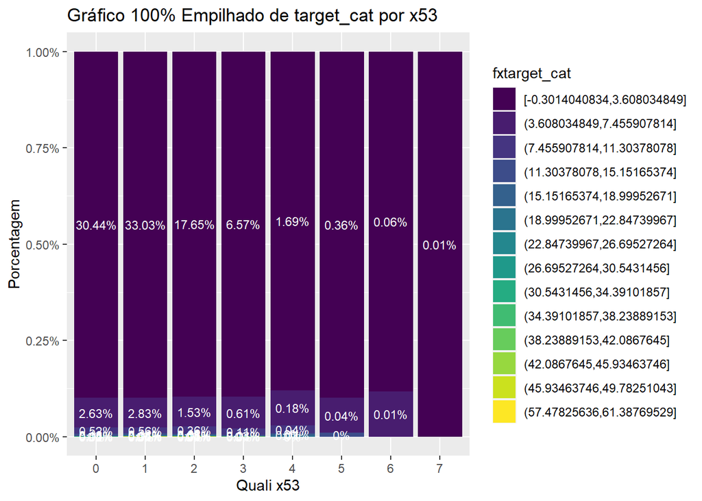

```r
ggplot(df1, aes(fill = fxtarget_cat, x = quali_x53)) +
  geom_bar(position = "fill") +
  geom_text(
    aes(label = paste0(round(100 * ..count../sum(..count..), 2), "%"),
        y = ..count..),
    position = position_fill(vjust = 0.5),
    stat = "count",
    size = 3,
    color = "white"  # Definir a cor do label como branca
  ) +
  labs(y = "Porcentagem", x = "Quali x53", title = "Gráfico 100% Empilhado de target_cat por x53") +
  scale_y_continuous(labels = scales::percent_format(scale = 1))
```

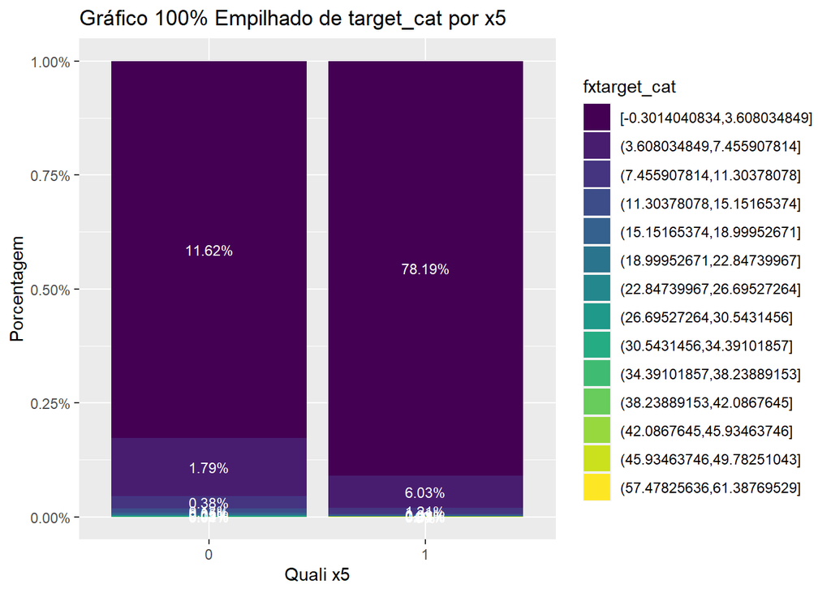

```r
ggplot(df1, aes(fill = fxtarget_cat, x = quali_x5)) +
  geom_bar(position = "fill") +
  geom_text(
    aes(label = paste0(round(100 * ..count../sum(..count..), 2), "%"),
        y = ..count..),
    position = position_fill(vjust = 0.5),
    stat = "count",
    size = 3,
    color = "white"  # Definir a cor do label como branca
  ) +
  labs(y = "Porcentagem", x = "Quali x5", title = "Gráfico 100% Empilhado de target_cat por x5") +
  scale_y_continuous(labels = scales::percent_format(scale = 1))
```

## 7ª etapa: Faça a análise bivariada das variáveis quantitativas.

### e) Análise de correlação de Pearson.

### f) Matriz de correlação de Pearson.

Selecionando as top 10 variaveis preditoras para fazermos a análise bivariada das variáveis quantitativas utilizando a correlação de pearson

#### 1º passo - Aplicar correlação de pearson nas variaveis quantitativas

```r
df_quant_corr <- cbind(dadosQuant,target)

# Calculando a matriz de correlação de pearson
correlacao <- cor(df_quant_corr)
head(correlacao)
```

```
##               x1            x3           x4            x6           x7
## x1  1.0000000000 -0.0008321963 -0.003624797  0.0019983860  0.002808924
## x3 -0.0008321963  1.0000000000  0.006272639 -0.0008101303  0.009103130
## x4 -0.0036247970  0.0062726392  1.000000000  0.0014666091 -0.002300537
## x6  0.0019983860 -0.0008101303  0.001466609  1.0000000000  0.002267395
## x7  0.0028089243  0.0091031298 -0.002300537  0.0022673949  1.000000000
## x8  0.0058303507 -0.0103189499  0.003445743  0.0058203056  0.006100992
##              x8             x9           x10           x11          x12
## x1  0.005830351  0.00246511743 -0.0037266397 -0.0033185100  0.001733434
## x3 -0.010318950 -0.00546138311  0.0009018064  0.0035956387  0.003357122
## x4  0.003445743  0.01061788503  0.0013006223 -0.0062222042  0.001243228
## x6  0.005820306 -0.00422931570 -0.0012971817  0.0076626340  0.003560071
## x7  0.006100992 -0.00250054618 -0.0010237875  0.0006392020 -0.004895799
## x8  1.000000000  0.00007731053 -0.0038687790  0.0003792376 -0.009975825
##             x13           x14           x15           x16          x17
## x1 -0.004842906 -0.0031592557  0.0087029717 -0.0026129316  0.006419444
## x3  0.002919105  0.0029147949 -0.0025357446 -0.0008546989  0.001497567
## x4  0.001858086 -0.0006099921  0.0065605744 -0.0084681219  0.018826962
## x6  0.010031673  0.0016472830 -0.0038515600  0.0102763446 -0.004083805
## x7 -0.003102100  0.0011078452 -0.0009946081 -0.0066364170 -0.003159171
## x8 -0.001574464 -0.0106802559  0.0018128831 -0.0105260891 -0.003207388
##             x18          x19          x20           x21          x22
## x1  0.002893706  0.002808261  0.005728961  0.0047423092 -0.005882706
## x3  0.004485556 -0.001955048  0.002593750  0.0123941360  0.006120782
## x4  0.005601628 -0.001153513  0.001124931 -0.0039129029 -0.007614048
## x6 -0.003484412 -0.001048058 -0.006666357  0.0013134625 -0.004016844
## x7  0.007156813  0.001882257 -0.001737479  0.0007169492  0.004134451
## x8  0.001887464  0.003072182  0.002812181  0.0114691307  0.006813752
##               x23           x24           x25          x26          x29
## x1 -0.00618961361 -0.0002203695 -0.0036067783  0.001251859  0.000506659
## x3 -0.00005792338  0.0048442317  0.0075284310 -0.005856561  0.004763369
## x4  0.00458324444  0.0112850686  0.0016697137  0.008994933  0.012549746
## x6 -0.00562415551 -0.0090347534 -0.0006650095 -0.001207830 -0.009878492
## x7 -0.00586981201 -0.0019424113  0.0043411741  0.003227073 -0.001112208
## x8 -0.00867553262 -0.0083400423  0.0027382845 -0.004047562 -0.008719404
##              x30          x31          x32          x33          x34
## x1  0.0030276575 -0.010529916 -0.001701896  0.001559493 -0.004327196
## x3  0.0115602799  0.003167645 -0.014326758 -0.001929161 -0.004382633
## x4  0.0033141957 -0.004270402  0.006871476  0.004851186 -0.003698816
## x6 -0.0084951775 -0.005873805 -0.002582066 -0.007628624  0.001026681
```

[output cut: 85 more lines]

```
## x8  0.005066854 -0.0012472445  0.0048782685  0.004995720  0.002807669
##             x102          x103          x104         x105         x106
## x1  0.0052599698  0.0084329252 -0.0006424986  0.002872365 -0.004468945
## x3 -0.0004619518  0.0101212431 -0.0114479541  0.004655969  0.005078409
## x4  0.0111674075 -0.0001789051  0.0088099422  0.005957455  0.005798902
## x6 -0.0066419905  0.0038405281  0.0026474702 -0.002841993 -0.001651108
## x7  0.0103721065  0.0093300214  0.0006673214  0.008618914 -0.007056624
## x8 -0.0037147151  0.0036996254 -0.0012010807  0.001730469 -0.008638824
##          target
## x1 -0.027028720
## x3  0.003440220
## x4 -0.013537320
## x6 -0.004892913
## x7  0.037973797
## x8  0.004259164
```